# WGD Classifier

SVM based WGD classifier that finds a good separation between samples which are and are not WGD in the ICGC dataset using percentage genome altered (PGA) and number of segments (nSeg).

```r
suppressMessages(library(GenomicRanges))
suppressMessages(library(ggplot2))
suppressMessages(library(cowplot))
suppressMessages(library("e1071"))
suppressMessages(library("yardstick"))
options(warnings=-1)
```

# Global setting

We use 4MB bins as using this bin size produces a similar number of segments on average (median) to the lpWGS data, therefore matching its resolution. This is logical in the sense that the modal minimum segment size is 2MB in the lpWGS (longitudinal metastasis cohort). As we take the median value in each 4MB bin, segments of 2MB are the minimum size segment that can be detected in 4MB bins.

```r
# What size?
bin_size = (10^6)*4

# Run binning?
run_binning = FALSE

beta0_adjust = 0.5
```

# Data Locations

These are the locations of the data we will use in this analysis.

```r
# Read in Will's previous analysis to compare to and to gather colon ids
will_analysis_table = "/Users/nowins01/Dropbox/CNA\ stability/working/GD predictor/GDclassPlots.PCAWG.ploidyCorr.tsv"

# Where are the ICGC calls?
icgc_call_dir = "~/Downloads/consensus.20170119.somatic.cna.icgc.public"

#Read in the chromosome lengths for hg19 (ICGC's genome)
chr.lengths = read.table("https://genome.ucsc.edu/goldenpath/help/hg19.chrom.sizes", stringsAsFactors = FALSE)

# Gather the colon ids
colons = read.table(will_analysis_table,
                    sep = "\t", header = T, stringsAsFactors = F)$samplename
```

# Binning

The genome is binned into a set size and those segments that overlap for each cancer sample. If multiple segments overlap within a bin we take the median copy number call according to relative overlaps of the segments in the bin.

# Classifier - Read in data

```r
# Convert to human readable
bs_MB = bin_size / 10^6

# Read in the binned segments
res_mat = readRDS(paste0("/Users/nowins01/Dropbox/CNA\ stability/working/GD_predictor_with_binning/binned_icgc_calls_",bs_MB,"MB.rds"))

# Read in the full table of data from Will's analysis
will_data = read.table(will_analysis_table,
                       sep = "\t", header = T, stringsAsFactors = F)
```

# Classifier - Data preparation

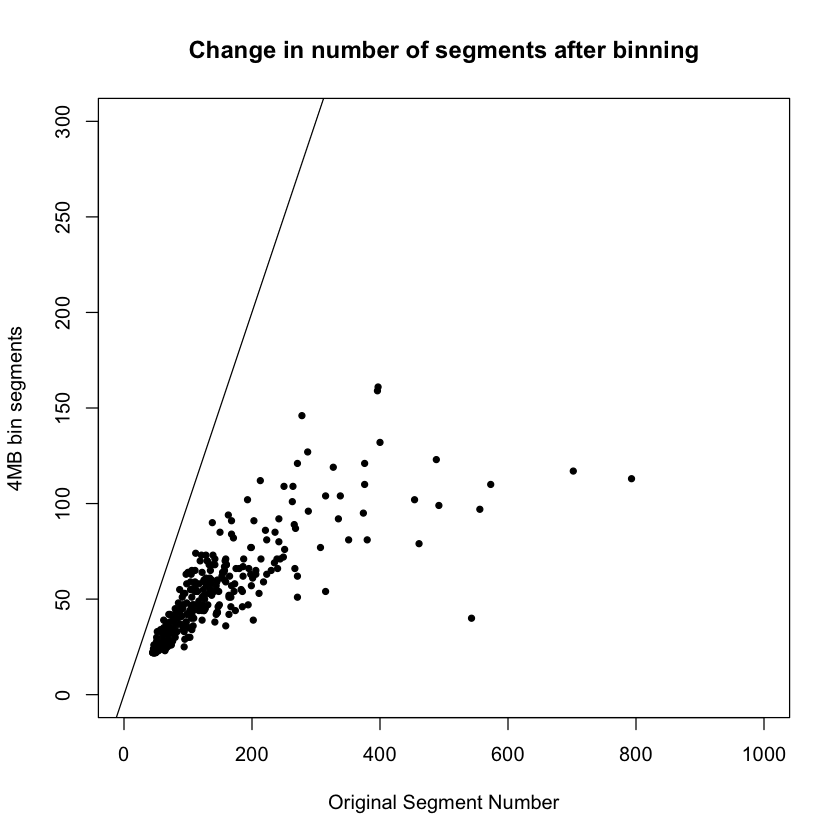

```r
# Calculate number of segments
number_segs = unlist(lapply(1:length(colons), function(s) {

  sum(unlist(lapply(1:22, function(chr) {

    calls = res_mat[res_mat$chr==chr,s+3]

    chr_cn = calls[calls>=0]

    length(rle(chr_cn)$values)

  })))

}))

# Median call
median_binned_ploidy = unlist(lapply(1:length(colons), function(s) {

  calls = res_mat[,3+s]

  calls = calls[calls>=0]

  ploidy = median(calls)

  return(ploidy)

}))

# Ploidy adjusted PGA
ploidy_adj_PGA = unlist(lapply(1:length(colons), function(s) {

  ploidy = median_binned_ploidy[s]

  calls = res_mat[,3+s]

  calls = calls[calls>=0]

  pga = length(which(calls!=ploidy)) / length(calls)

  return(pga)

}))

# Create a dataframe of new results
nsegs_gc = data.frame(samplename = colons, george_nsegs = number_segs,
                      george_pga = ploidy_adj_PGA, med_bin_ploidy = median_binned_ploidy)

# Merge with the previous results
all_data = merge(nsegs_gc, will_data, by = "samplename")

# Make a plot showing the change in the number of segments after binning
plot(all_data$noSegments, all_data$george_nsegs, pch = 20, xlim = c(0,1000), ylim = c(0,300),
     main = "Change in number of segments after binning",
     xlab = ("Original Segment Number"), ylab = paste0(bs_MB,"MB bin segments"))
abline(0, 1)
```

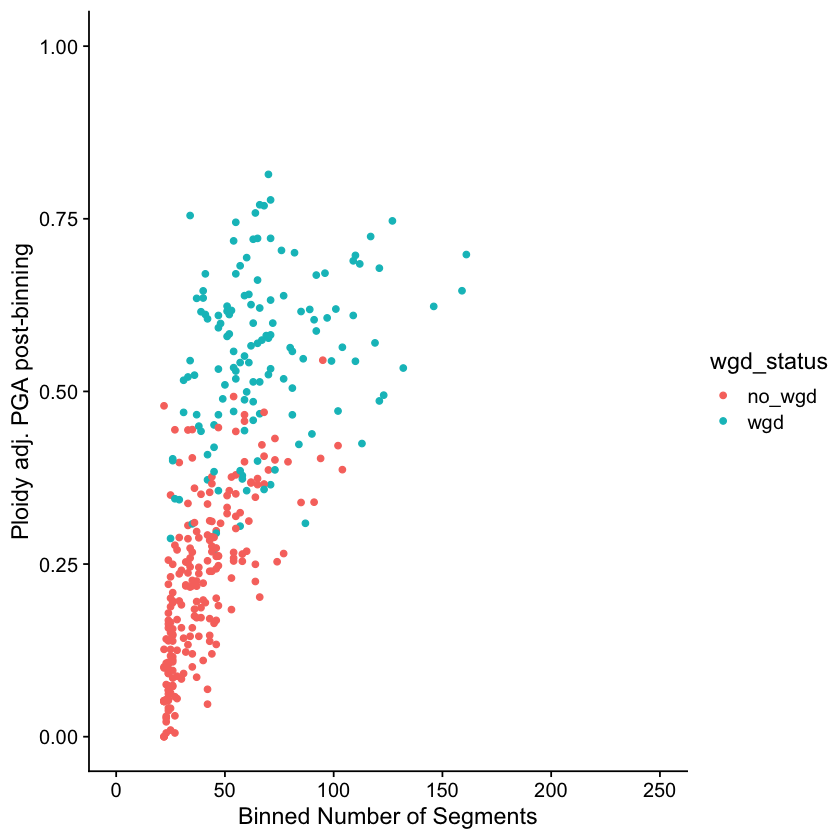

```r
# Make a plot of number of segments after binning and the ploidy adjusted PGA
ggplot(all_data, aes(x = george_nsegs, y = george_pga, col = wgd_status)) + ylim(0,1) + xlim(0,250) +
  xlab("Binned Number of Segments") + ylab("Ploidy adj. PGA post-binning") +
  geom_point() + theme_cowplot()
```

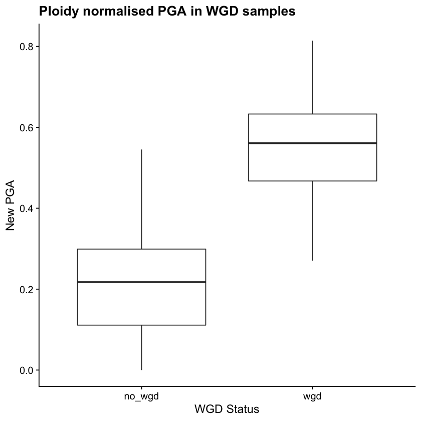

```r
# Make boxplot of ploidy adjusted PGA in samples classified as either WGD or not
ggplot(all_data, aes(y = george_pga, x = as.factor(wgd_status))) +
  xlab("WGD Status") + ylab("New PGA") +
  ggtitle("Ploidy normalised PGA in WGD samples") +
  geom_boxplot() + theme_cowplot()
```

# Classifier - Run classifier

This code uses a SVM to find the best separation of WGD samples against non-WGD across the number of segments, ploidy adjusted PGA axis in the binned analysis.

```
[1] "beta0:  -4.07638059352384"
```

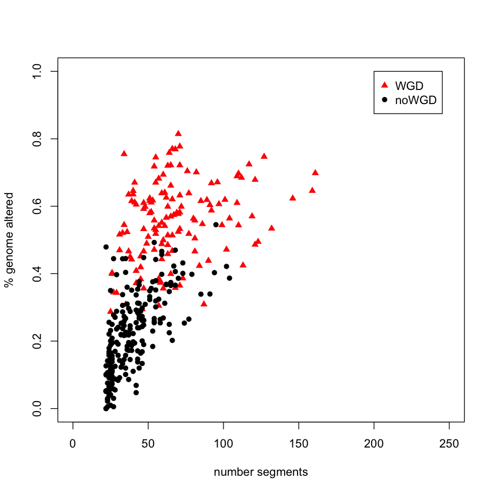

```r
# Add column denoting WGD status
all_data$WGD <- T
all_data$WGD[all_data$wgd_status == "no_wgd"] <- F

# Create a dataframe for the SVM analysis specifically
dataf <- data.frame(as.factor(all_data$WGD),
                    all_data$george_pga,
                    all_data$george_nsegs)
# Give columns readable names
names(dataf) <- c("WGD","percGenomeAbberated","noSegments")

# Create a plot of the segment-pga axis
plot(dataf$noSegments[dataf$WGD==T],
     dataf$percGenomeAbberated[dataf$WGD==T],
     xlab="number segments",
     ylab = "% genome altered",
     xlim=c(0,250),ylim=c(0,1),
     col="red",
     pch=17)
points(dataf$noSegments[dataf$WGD==F],
       dataf$percGenomeAbberated[dataf$WGD==F],
       col="black",
       pch=16)
legend(200,1,c("WGD","noWGD"),col=c("red","black"),pch=c(17,16))

# Create a dataframe for the SVM analysis specifically
dataf <- data.frame(as.factor(all_data$WGD),
                    all_data$george_pga,
                    all_data$george_nsegs)
# Give columns readable names
names(dataf) <- c("WGD","percGenomeAbberated","noSegments")

# Use a SVM to create the best separation between the WGD and non-WGD samples
fit = svm(WGD ~ ., data=dataf, scale = F, kernel = "linear", cost = 5)

# Print the betas
b0 = fit$rho
beta = t(fit$coefs)%*%as.matrix(dataf[fit$index,c(2,3)])
b1<-beta[[1]]
b2<-beta[[2]]
print(paste("beta0: ",b0))
```

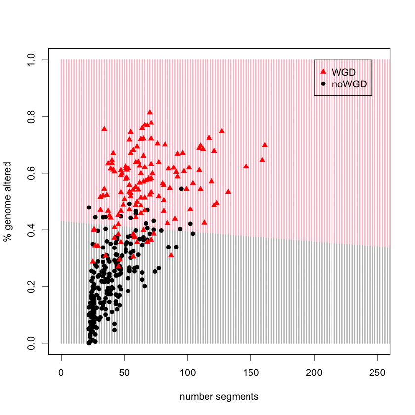

```r
# Use a SVM to create the best separation between the WGD and non-WGD samples
fit = svm(WGD ~ ., data=dataf, scale = F, kernel = "linear", cost = 5, probability=TRUE)

# Prep a grid to show the areas considered to be of the two classes
xdots <- seq(0,1000,2)
ydots <- seq(0,1,0.002)
mygrid <- expand.grid(X1 = xdots, X2 = ydots)
names(mygrid) <- c("noSegments","percGenomeAbberated")
predictions <- predict(fit,mygrid, probability=TRUE)

# Plot the results of the classifier on top of the segments-pga axis
plot(mygrid, col = c("grey","pink")[as.numeric(predictions)],
     pch = 20, cex = 0.2,
     xlim=c(0,250),ylim=c(0,1),
     xlab="number segments",
     ylab = "% genome altered")
points(dataf$noSegments[dataf$WGD==F],
       dataf$percGenomeAbberated[dataf$WGD==F],
       col="black",
       pch=16)
points(dataf$noSegments[dataf$WGD==T],
       dataf$percGenomeAbberated[dataf$WGD==T],
       col="red",
       pch=17)
legend(200,1,c("WGD","noWGD"),col=c("red","black"),pch=c(17,16))
```

```r
# Provide metrics on how well the classifier worked
predictionsOnMyData <- predict(fit,dataf[,c("noSegments","percGenomeAbberated")])
data_pred <- cbind(dataf,predictionsOnMyData)
# What fraction of positives are actually true?
ppv(data_pred,truth=data_pred$WGD,estimate=data_pred$predictionsOnMyData)
```

A tibble: 1 × 3

| .metric <chr> | .estimator <chr> | .estimate <dbl> |
| --- | --- | --- |
| ppv | binary | 0.9030837 |

```r
# What fraction of negatives are actually false?
npv(data_pred,truth=data_pred$WGD,estimate=data_pred$predictionsOnMyData)
```

A tibble: 1 × 3

| .metric <chr> | .estimator <chr> | .estimate <dbl> |
| --- | --- | --- |
| npv | binary | 0.8837209 |

```r
# Finally this is what we've all needed
intercept = b0/b1
gradient = -b2/b1
print(paste("decision boundary: pG = ",signif(gradient, digits = 3),".nS"," + ",signif(intercept, digits = 3),sep=""))
```

```
[1] "decision boundary: pG = -0.000355.nS + 0.432"
```

# Report how the classifier is performing ± the SVM boundary line

Here we identify that the decision boundary does not perform better than a coin toss ±0.5 the decision boundary.

```r
numbers = seq(0, 1, by=0.01)


suppressWarnings({for (i in 1:length(numbers)) {

dataf$WGD_class_lower = dataf$percGenomeAbberated >= (dataf$noSegments * +gradient) + (b0 + numbers[i]) / b1
dataf$WGD_class_upper = dataf$percGenomeAbberated <= (dataf$noSegments * +gradient) + (b0 - numbers[i]) / b1

predictionsOnMyData <- predict(fit,dataf[,c(2,3)])
predictionsOnMyData <- predictionsOnMyData[dataf$WGD_class_lower==dataf$WGD_class_upper]
Middles <- dataf[dataf$WGD_class_lower==dataf$WGD_class_upper, ]

data_pred <- cbind(Middles,predictionsOnMyData)
# What fraction of positives are actually true?
ppv(data_pred,truth=data_pred$WGD,estimate=data_pred$predictionsOnMyData)

# What fraction of negatives are actually false?
npv(data_pred,truth=data_pred$WGD,estimate=data_pred$predictionsOnMyData)

if (i ==1) {
	final_row = cbind(numbers[i], ppv(data_pred,truth=data_pred$WGD,estimate=data_pred$predictionsOnMyData)[3], npv(data_pred,truth=data_pred$WGD,estimate=data_pred$predictionsOnMyData)[3])
}

	new_row = cbind(numbers[i], ppv(data_pred,truth=data_pred$WGD,estimate=data_pred$predictionsOnMyData)[3], npv(data_pred,truth=data_pred$WGD,estimate=data_pred$predictionsOnMyData)[3])
	final_row = rbind(final_row,new_row)

}
})

#### pick the right upper and lower boundary
names(final_row)[2:3] <- c("ppv", "npv")
final_row = na.omit(final_row)

#find the value of the decision boundary where PPV and NPV is closest to a coin toss - 0.5
final_row$closest <- abs(final_row$ppv-0.5)+abs(final_row$npv-0.5)
upper_lower_boundary = subset(final_row, final_row$closest==min(final_row$closest))

#print values
print(paste("the upper and lower boundary that is is closest to a coin toss is ", round(upper_lower_boundary[1,1],digits=1)))
print(paste("PPV ", upper_lower_boundary[1,2], " and NPV ", upper_lower_boundary[1,3]))
```

```
[1] "the upper and lower boundary that is is closest to a coin toss is  0.5"
[1] "PPV  0.566666666666667  and NPV  0.5"
```

# Adjusted margins of SVM

Plot of the data with adjusted margins, reflecting the uncertain area within the SVM decision boundary. If a sample falls in this new margin it has a PPV of 0.57 and an NPV of 0.5, nearing a 50% chance of either being WGD or not WGD.

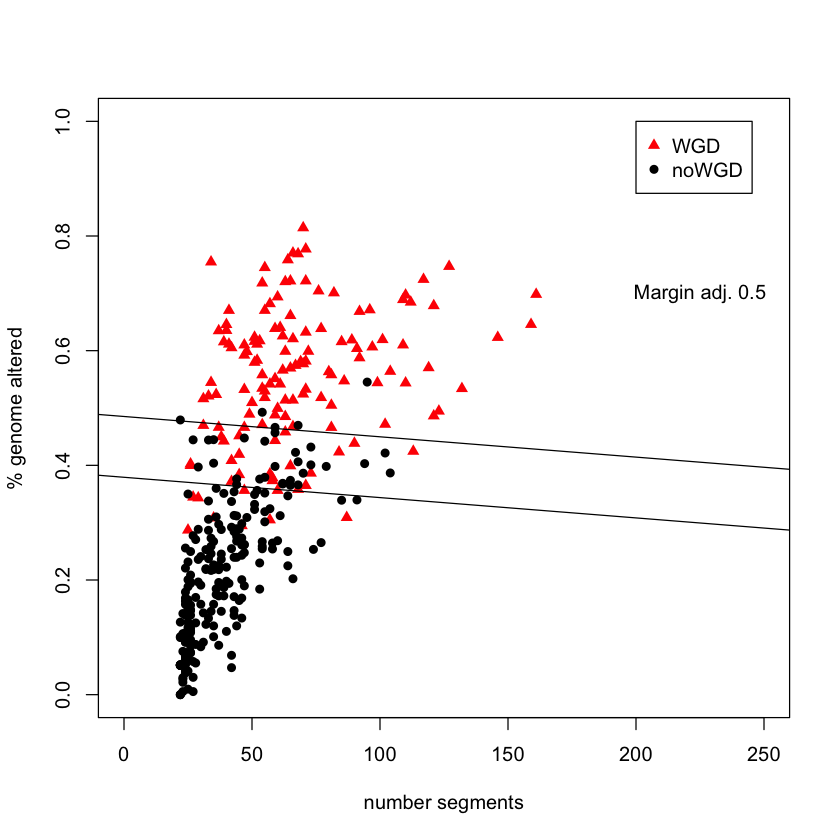

```r
# Create a plot of the segment-pga axis
plot(dataf$noSegments[dataf$WGD==T],
     dataf$percGenomeAbberated[dataf$WGD==T],
     xlab="number segments",
     ylab = "% genome altered",
     xlim=c(0,250),ylim=c(0,1),
     col="red",
     pch=17)
points(dataf$noSegments[dataf$WGD==F],
       dataf$percGenomeAbberated[dataf$WGD==F],
       col="black",
       pch=16)
legend(200,1,c("WGD","noWGD"),col=c("red","black"),pch=c(17,16))
abline(a = (b0+beta0_adjust)/b1, b = -b2/b1)
abline(a = (b0-beta0_adjust)/b1, b = -b2/b1)
text(225, 0.7, labels = paste0("Margin adj. ",beta0_adjust))
```

```r
# Finally this is what we've all needed
intercept = (b0+beta0_adjust)/b1
gradient = -b2/b1
print(paste("lower boundary: pG = ",signif(gradient, digits = 3),".nS"," + ",signif(intercept, digits = 3),sep=""))
```

```
[1] "lower boundary: pG = -0.000355.nS + 0.379"
```

```r
# Finally this is what we've all needed
intercept = (b0-beta0_adjust)/b1
gradient = -b2/b1
print(paste("upper boundary: pG = ",signif(gradient, digits = 3),".nS"," + ",signif(intercept, digits = 3),sep=""))
```

```
[1] "upper boundary: pG = -0.000355.nS + 0.485"
```

The PPV and the NPV on either side of this new margined decision boundary is:

```r
dataf$WGD_class_lower = dataf$percGenomeAbberated >= (dataf$noSegments * +gradient) + (b0 + beta0_adjust) / b1
dataf$WGD_class_upper = dataf$percGenomeAbberated <= (dataf$noSegments * +gradient) + (b0 - beta0_adjust) / b1


predictionsOnMyData <- predict(fit,dataf[,c(2,3)])
predictionsOnMyData <- predictionsOnMyData[dataf$WGD_class_lower!=dataf$WGD_class_upper]
not_Middle = dataf[dataf$WGD_class_lower!=dataf$WGD_class_upper, ]
data_pred <- cbind(not_Middle,predictionsOnMyData)
# What fraction of positives are actually true?
print(paste("Above and below the decision margin PPV is ", ppv(data_pred,truth=data_pred$WGD,estimate=data_pred$predictionsOnMyData)))

# What fraction of negatives are actually false?
print(paste("Above and below the decision margin NPV is ", npv(data_pred,truth=data_pred$WGD,estimate=data_pred$predictionsOnMyData)))
```

[output not shown]